# 2.07-Binary-Search-Trees

### Topics Covered

- Introduction to Trees
- Introduction to Binary Search Trees
- Insert
- Contains
- Remove Intro
- Remove Node - no children
- Remove Node - one child
- Remove Node - two children
- Real-Life Applications of Binary Search Trees (BSTs)

### Trees Intro

In the previous section, we briefly mentioned that arrays and linked lists belong to this group called Linear Data Structures. This means that they're all limited to only one dimension. They can't represent any kind of hierarchy between their elements. To overcome this issue, new data structures were created. Ones that can be organized on more than one level and can reflect some sort of hierarchy. One of these structures is the tree. Just like linked lists, trees are also built using node objects, but this time they follow different rules

A tree contains one node that is at the top level, which branches out into other nodes, and those nodes can in turn branch out into different nodes, and so on. Notice that the nodes are now placed on different levels, and because of how they are connected, we can't go from one to the next in a linear fashion like we did with linked Lists

Let's define some key terms we're going to use when we talk about trees

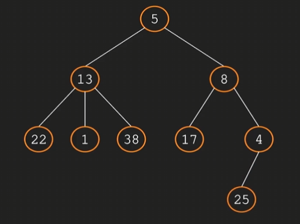

- **Nodes** :We already mentioned nodes. They're the building blocks of trees. They share the same name with the objects we use to create linked lists, and they also carry a value and some other properties
- **Edges**: Edges also called links and sometimes arcs, are the connections between nodes. You can think of them as being similar to the next or previous pointers we had with linked lists. They are the things that keep the nodes connected to the tree.
- **Parent** : Parents are nodes which have connections to other nodes located in the next level below them in the tree hierarchy. In our example, `5` is a parent for both `13` and `8`. And `8` is a parent for `17` and `4`, and so on

One thing to note here is that we can consider a node being a parent to another node, only if it has a direct link to it. So for instance, we can't say that `8` is a parent to `25` because they don't have a direct connection between them.

- **Ancestor** : `8` will be an ancestor to `25`, and so would 5 if we were to go from `25` to its parent and then keep going on the hierarchy chain, all the nodes until the top level node can be considered ancestors to `25`
- **Child** : A node that has a parent is called a child. In our example, `22`,`1` and `38` are all children of 13.The parent child relation we just discussed in the previous bullet point is still valid. We can't say that 1 is a child to `5`. For example, `1` is the child of `13`
- **Descendant** : If we wanted to describe `1` in relation to `5`, we would say that 1 is a descendant of `5`
- **Sibling** : These are nodes that have the same parent. The node `22`, `1` and `38` are also siblings. They're all children of `13`.
- **Root** : The top most node is called the root. The root is the only node that doesn't have a parent and can only have children. A tree can only have one root. In our tree that is the `5` node
- **Leaf** : are the ones that do not have any children. They're the end of the line for all the branches of our tree. Leaves are not limited in number. A tree can have as many as possible. The leaves of our tree are `22`, `1`, `38`, `17` and `25`.Any node that is neither the root nor a leaf is usually called an inner node or internal node

Let's talk about some rules that we should follow to be considered a valid tree.

- We already established that a tree can have only one root, although there are some implementations that can have multiple nodes at the first level of the tree. From a mathematical standpoint, a tree can have only one root
- Another rule is that a node can have any number of children from none, in which case there leaves toas many as we want. Some implementations, however, limit that number to either 2 or 3 children
- Every node needs to have only one parent. The exception to that is of course the root, which is the only node without a parent. But if you look at this example, you won't see any nodes that have two parents. Something like this(refer below snapshot), for instance, with `25` having both `17` and `4` as parents is not allowed. This is not a tree any more

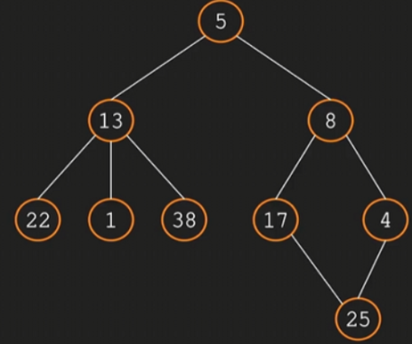

- The last rule would be that nodes on the same level should not be connected. For example, `17` and `4`.If they had a link between them, it would make this a different data structure altogether.

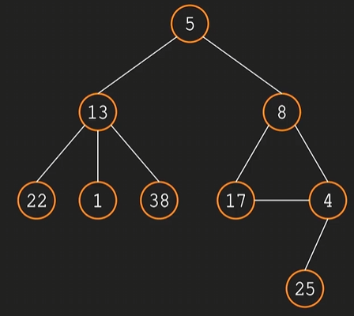

Let's have a look at a few more trees for practice

This one, for example, is a tree with two levels the root and its five children. This is a very basic tree where all the nodes except the root are leaves

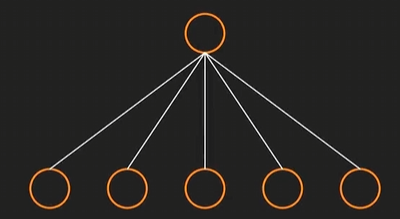

This next one is also a tree, but this time it has more levels than the previous one. The first three nodes only have one child each. The branching starts only at the last level.

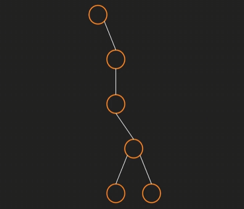

In this example, we have an organizational chart of a company.

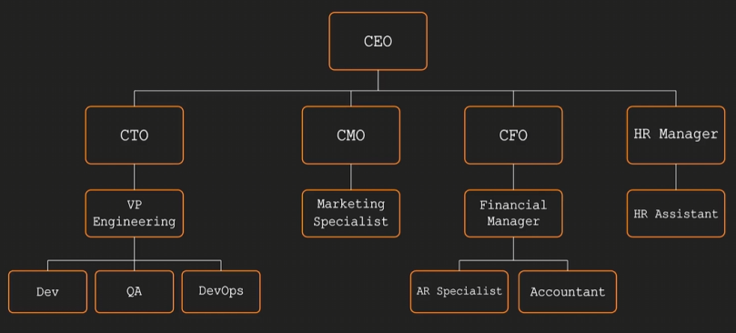

Another example of how a tree can be used comes this time from our operating system's folder. Structures are created under the hood with trees. In this example, the project folder is the parent of the public folder. The source folder and three files. These three files are leaves, so they don't have any descendants, but the public and source folders do. Public has only two files inside it that happen to also be leaves, but source branches out into two other folders, and those folders have in turn other folders inside them. So you can now see that when you're navigating through folders, you're actually going up and down a tree structure

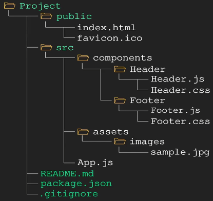

In above image, the tree is displayed horizontally because that's how we're used to seeing folders. But if we were to flip it, you can see the same top to bottom hierarchy where parent folders branch out into different child folders

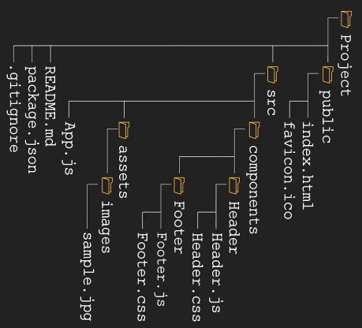

Another example, which is even more technical is the Dom, the Document Object Model, which browsers use to display web pages. Even though the Dom is said to be built with a tree like structure, which implies it's not really the basic tree that we just learned, but rather some sort of variation. I still think it's a good example. As we can see from this image, the root of our Dom is the HTML element. This element branches into a head element, a body element, and it goes on and on until they reach their last element

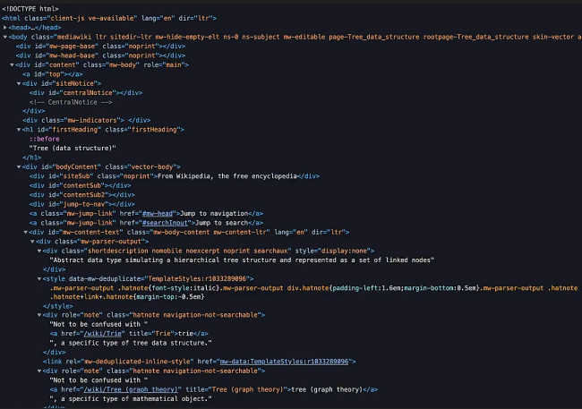

So if we were to draw some conclusions, we can say that trees were created out of the necessity to represent hierarchy between elements which we could not reliably do using linear data structures. Trees have only one root, which can have multiple child nodes, and those nodes can themselves branch out into other nodes until we reach the leaves, which are at the bottom level of the tree and don't have any children. And this is all we need to know for now about the tree data structure.

### Introduction to Binary Search Trees

why binary? The word binary has something to do with the number two in the context of a tree.

1. Binary means that any node in the tree can have at most two children. They can have no children, in which case they are leaves. They can have one child or two, but never more than that. This tree we see in this image below is a binary tree. There is no node in this tree that has more than two children.
2. The second rule of a binary search tree is that all the values to the left of a node have to be smaller than any of the values to its right.
3. Duplicates are typically not accepted in a binary search tree. Having duplicates will greatly increase the complexity of the tree, and it's generally advised that a binary search tree should only contain unique values.

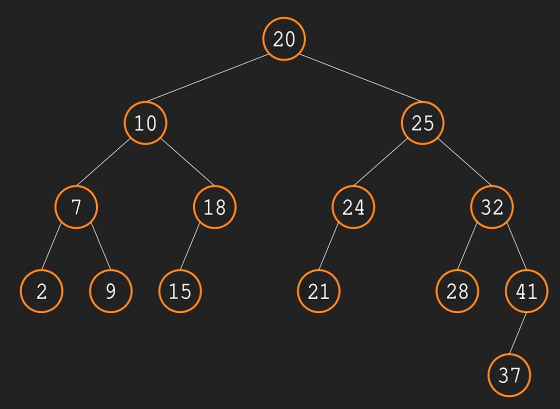

Another aspect to think about is what type of data we store. In our example there were numbers, but our tree can technically work with any values that can be compared, like letters, for example. Our binary search tree could have the letter L as the root, and then distribute all the letters that come before L to its left and all that come after it to the right. Keeping in mind that all the subtrees should also follow this rule

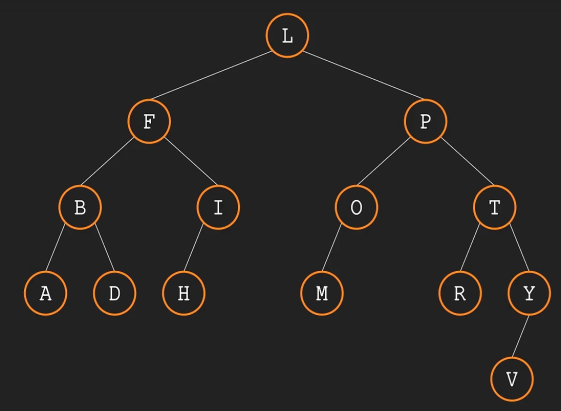

Because of how the values are stored in a binary search tree. Operations like insertion, searching, and deletion can be very efficient. This is what the term search in the binary search tree stands for. It's pretty much a statement of this data structures purpose

If we were to do a short recap, we can say that binary search trees are a hierarchical tree structure where each node can have at most two children. The left child is less than its parent and the right child is greater than it.

**Code Implementation**

We would again need to create a node class which will contain a value property to store the information, and then the two pointers for the children nodes. Since we can only have two child nodes, and they're normally represented to the left and right of the parent node, the convention is to name the properties left and right, and both of them will start with a default value of none. And that is what all the node class needs

```python
class Node:
    def __init__(self, value):
        self.value = value
        self.left = None
        self.right = None
```

Let's now define the binary search tree class. So what properties do you think this class could contain?

When we did the linked lists, we had the head and tail properties which acted as entry points and we didn't actually store any other nodes besides that. And it's the same story with our tree. Since we're representing it as a linked structure, we don't need to store all the nodes, but only the entry point. And that entry point is the `root node`.

So this root node will be the first node to be added in our tree. And all the other ones will be placed either to its left or to its right, depending on the values. With the linked lists. We also had a length or size property which kept count of the nodes we had in the list. And if we needed to know the number of nodes, I guess we could have something similar for our tree class as well

```python
class BinarySearchTree:
    def __init__(self):
        self.root = None
```